# Reproducible Research: Peer Assessment 1

Savvas Pavlidis

Sunday, September 14, 2014

## Loading and preprocessing the data

The code does not assume that the data used are already in the working directory. So it will check if the data file exists in the current working directory. If not, it will check if the compressed zip file exists and unzip it, otherwise, will download it from Internet from the given URL where the compressed datafile exists, and then proceed to unzip it.  
Then load data to a dataframe, and by reading NA assume that is null value.

```r
if (!file.exists("activity.csv")) {
  if (!file.exists("activity.zip")) {
    download.file("https://d396qusza40orc.cloudfront.net/repdata%2Fdata%2Factivity.zip",
                    destfile="activity.zip")
  }
  unzip("activity.zip")
}
data<-read.csv("activity.csv",na.strings="NA",stringsAsFactors=FALSE)
```

## What is mean total number of steps taken per day?

We will ignore all records with NA in steps. So we need to take the SUM for EACH day in steps, excluding NA’s. This is easily accomplished by an apply function, and as we want a table, a tapply function is what we want. Apply the sum function to sum the steps, in each group day (given by date$date) and exclude any NA’s.  
A histogram follows.

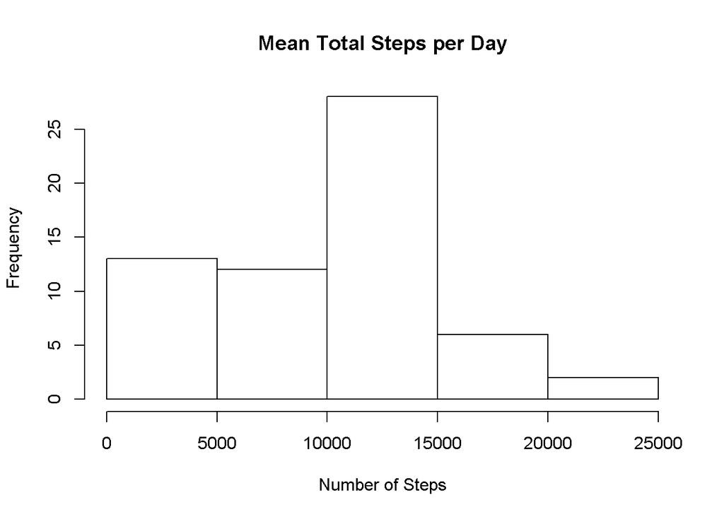

```r
stepsperday<-tapply(data$steps,data$date,FUN=sum,na.rm=TRUE)

hist(stepsperday,main="Mean Total Steps per Day",xlab="Number of Steps")
```

The mean and median can be calculated easily

```r
mean(stepsperday)
```

```
## [1] 9354
```

```r
median(stepsperday)
```

```
## [1] 10395
```

## What is the average daily activity pattern?

### Time series plot

To investigate the daily activity pattern, we need to see what is it done in each interval, thus now we need to take the mean for all days group by each interval. Each interval is actually a specific period of time of the day. A each interval is 5 minutes, we see that there a total of 288 different intervals, which means a total of 1440 minutes, which is a full day (24 hours) Replaced the interval data value with the actual time in hour:minutes to have a more proper plot.

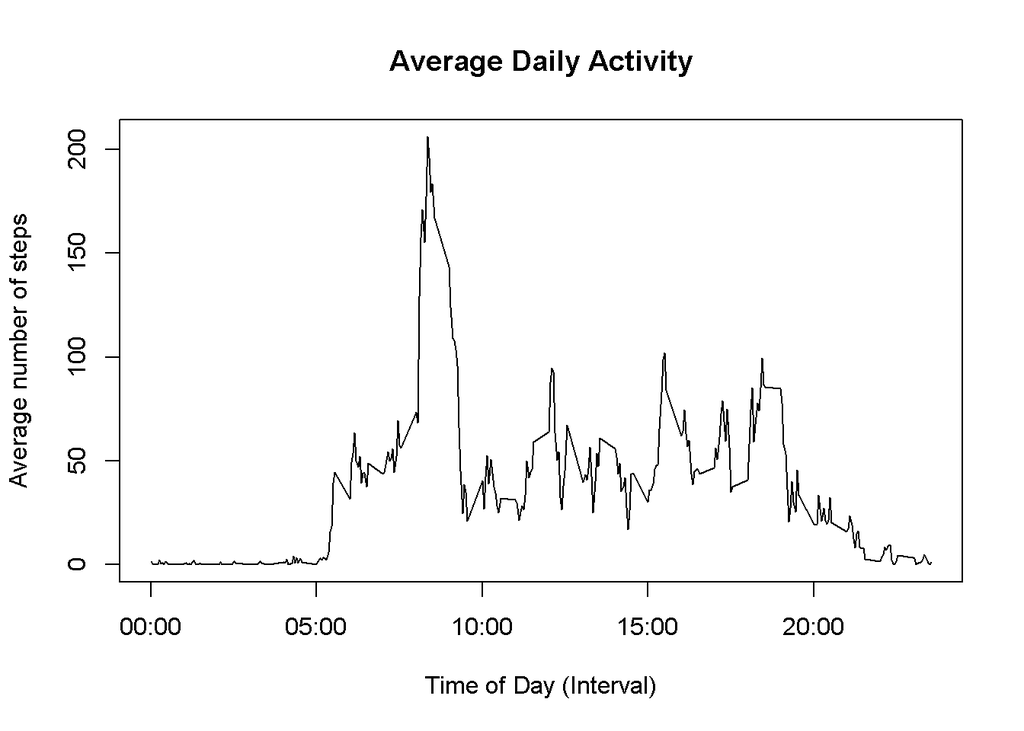

```r
pattern<-tapply(data$steps,data$interval,mean,na.rm=TRUE)
plot(names(x=pattern),y=pattern,type="l",main="Average Daily Activity",xlab="Time of Day (Interval)",ylab="Average number of steps",xaxt="n")
axis(1,at=c(0,500,1000,1500,2000),labels=c("00:00","05:00","10:00","15:00","20:00"))
```

### The interval with the maximum average number of steps

```r
names(which.max(pattern))
```

```
## [1] "835"
```

```r
which.max(pattern)
```

```
## 835
## 104
```

## Imputing missing values

### Missing values

Calculate the total number of missing values

```r
sum(is.na(data$steps))
```

```
## [1] 2304
```

### Strategy for filling missing values

We assume that for intervals that have no value (NA), we can replace the missing value with the average we found for the same interval. A different strategy can be easily accomplished in the code, replacing the assign with another function if required.

### Create new dataset with missing values filled in

We scan the whole dataframe in a for loop, and whenever there is a NA value in steps, we assign there the already calculated average mean for all days.

```r
for ( i in 1:nrow(data) ) {
    if ( is.na( data$steps[i])) {
      data$steps[i]<-pattern[ as.character(data$interval[i])]
    }

}
```

### Results with missing values filled in

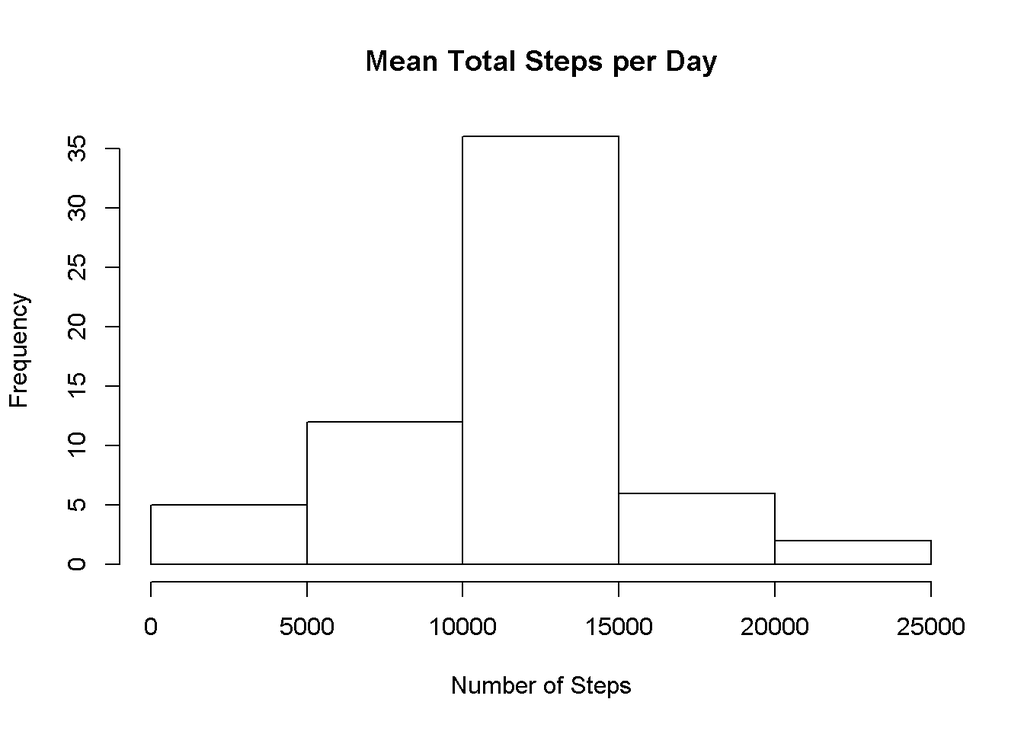

```r
stepsperday<-tapply(data$steps,data$date,FUN=sum,na.rm=TRUE)

hist(stepsperday,main="Mean Total Steps per Day",xlab="Number of Steps")
```

The mean and median now

```r
mean(stepsperday)
```

```
## [1] 10766
```

```r
median(stepsperday)
```

```
## [1] 10766
```

## Are there differences in activity patterns between weekdays and weekends?

This can be easily been seen if we make a plot with the average number of steps made on weekend and weekdays. Firstly we must separate the data in weekdays and weekends. Thus we need to create a new column in the datafram as a factor with two values, weekday and weekend. We take the day and get the numeric equivalent of the weekday. Day 0 and 6 are Sunday and Saturday. So we create two subsets by subsetting according to day. Then we average to get the activity of each group of days and plot them on one graph to see the differences.

[figure not shown]

```r
data$typeofday<-as.POSIXlt(as.Date(data$date))$wday
pat_weekend<-data[ data$typeofday==0 | data$typeofday==6,]
pat_weekdays<-data[ data$typeofday!=0 & data$typeofday!=6,]
p1<-tapply(pat_weekend$steps,pat_weekend$interval,mean,na.rm=TRUE)
p2<-tapply(pat_weekdays$steps,pat_weekdays$interval,mean,na.rm=TRUE)

plot(names(x=p1),y=p1,type="l",main="Average Weekdays/Weekend Activity",xlab="Time of Day (Interval)",ylab="Average number of steps",xaxt="n",col="red")
axis(1,at=c(0,500,1000,1500,2000),labels=c("00:00","05:00","10:00","15:00","20:00"))
lines(names(x=p2),y=p2,col="green")
legend( list(x=1650,y=170),c("Weekdays","Weekends"), lty=c(1,1), col=c("red","green"))
```